# Anova Tutorial

David W. Vinson

3/13/2017

## Analysis of Variance (anova)

Anova is a parametric test meaning that the distribution has to abide by certain assumptions. You can find a nice review of it here: http://www.unh.edu/halelab/BIOL933/labs/lab5.pdf. We’ll go over a few of them here (simple). Anova is used to test whether there is a signficant difference in responses between different categories.

For this example, we’ll use a dataset from a recent paper that looks at how language influences the remembered location of a car, positioned on a hill. Here’s the actual experiment: http://davevinson.com/exp/vzm/2/z2.html

First let’s set out wd and load the *data* (which can be found on https://github.com/DaveVinson)

```r
setwd("/Users/Dave/Desktop")
results <- read.csv("anova-data.csv")
```

Let’s see what it looks like.

```r
results[1:10,]
```

```
##     dir     lang     newx
## 1    up backward 172.3968
## 2  down  forward 176.9728
## 3  down  forward 139.1945
## 4    up backward 131.2663
## 5  down  forward 323.7229
## 6    up backward 154.4654
## 7    up backward 141.1632
## 8  down  forward 112.2175
## 9    up  forward 121.7419
## 10 down backward 120.4649
```

Here we’re interested in “dir” for direction “lang” for language used and “newx” a measure of the placement of the car along the slope of the hill. We want to know if language “the car moved forward” or “the car moved backward” influences whether participants remember the car as farther away from its actual location when the car is facing **up** the hill or **down** the hill. So we’ll use anova to evaluate whether this is the case.

Let’s center our data around zero:

```r
results$newx = results$newx-(127.7) # we subtract the actual location of the car on the slope
```

### First we need to determine if response variable distribution abides by anova assumptions

##### (1) The DV must be normally distributed

The idea behind normal distribution in anova is to avoid false positives, falsing predicting some data point as coming from a speciifc category). However, anova is typically robust against violations of normality (Glass et al. 1972, Harwell et al. 1992, Lix et al. 1996)

There are a few ways to test for normality (does not exhibit Skew or Kurtosis). The Shapiro test is the most conservative test. If it is significant, then we have a problem.

```r
shapiro.test(results$newx) #super conservative
```

```
##
##  Shapiro-Wilk normality test
##
## data:  results$newx
## W = 0.7102, p-value < 2.2e-16
```

The q-q plot (or quantile by quantile plot) shows whether the first half of the data is different than the second half (e.g., did it come from the same population?). If lots of points do not fall on this line, then we might a problem.

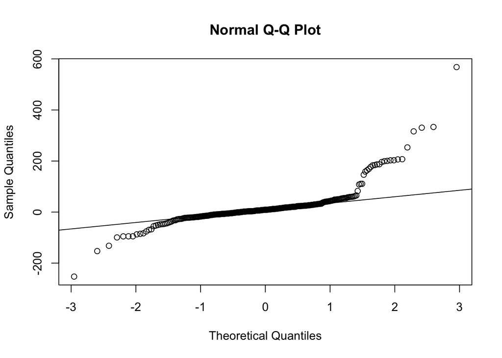

```r
qqnorm(results$newx) #more conservative
qqline(results$newx) #more conservative
```

Least conservative (but most common) is just to eye-ball your histogram for normality

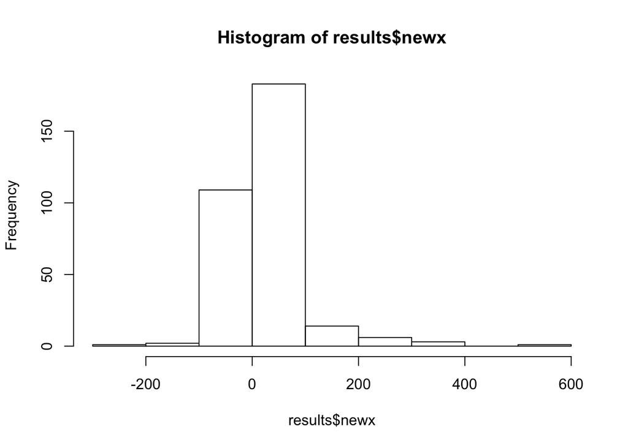

```r
hist(results$newx) #best to just eye ball it.
```

#### Looks like it’s not normal… so what to do?

We can apply some techniques to normalize such as log transformation for skewed data or trimming (in this case).

Trimming can be applied when your data appear to be centered, but not normal (e.g., certain types of kurtosis) due to outliers on both sides of the distribution.

```r
#here I trim my dataset to take only those who are 1.5 standard deviations away from the mean
upper=mean(results$newx)+(1.5*(sd(results$newx)))
lower=mean(results$newx)-(1.5*(sd(results$newx)))
test = results[results$newx<upper,]
results=test[test$newx>lower,]
```

Let’s check for normality:

```r
shapiro.test(results$newx) #super conservative
```

```
##
##  Shapiro-Wilk normality test
##
## data:  results$newx
## W = 0.97312, p-value = 2.916e-05
```

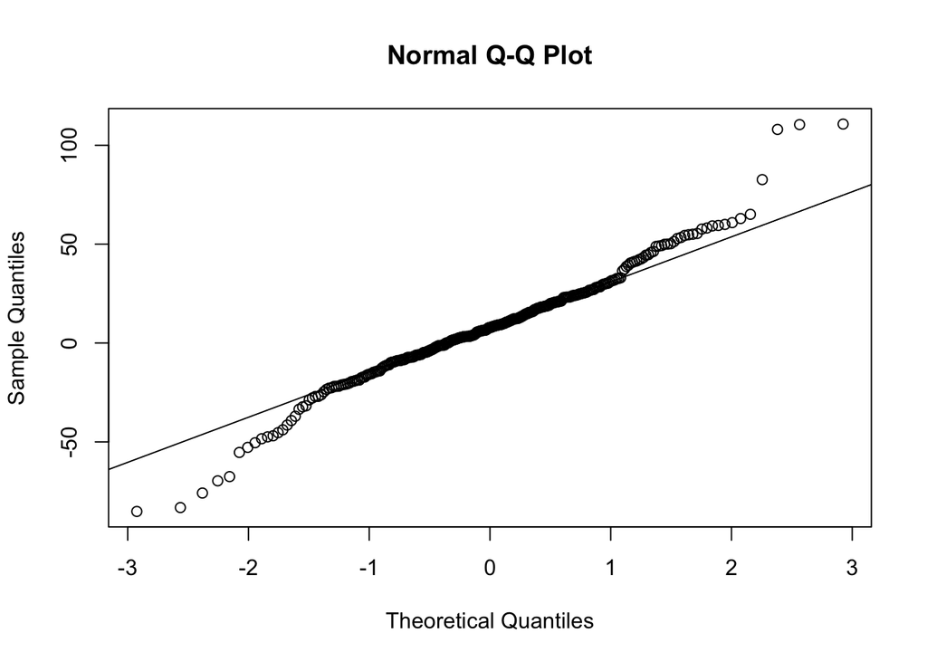

```r
qqnorm(results$newx) #more conservative
qqline(results$newx) #more conservative
```

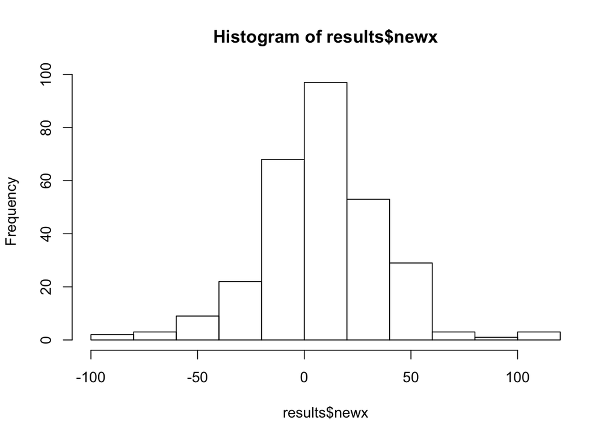

```r
hist(results$newx) #best to just eye ball it.
```

Looking good! (although not perfect, we can move forward)

### (2) The residuals must be normally distributed

Build the model to get residuals.

```r
#Note we are interested in an interaction between car facing direction and language use
mod<-lm(newx ~ dir*lang, results)
results$resids <- residuals(mod)
results$preds <- predict(mod)
results$sq_preds <- results$preds^2
```

Check for normality

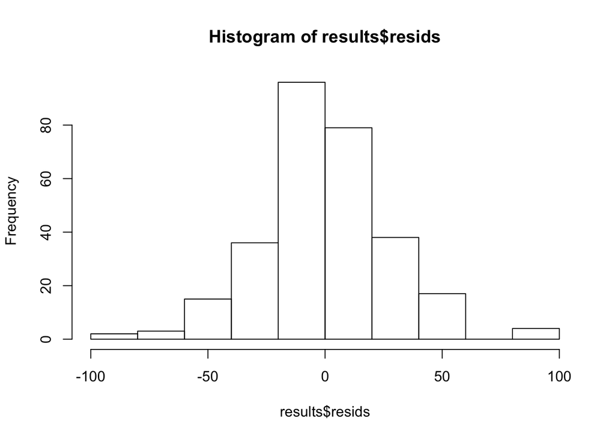

```r
#shapiro.test(results$resids) #super conservative
#qqnorm(results$resids) #more conservative
#qqline(results$resids) #more conservative
hist(results$resids) #best to just eye ball it.
```

### (3) variances must be homogeneous (equal across different groups)

Levene’s Test for homogenity of variances is perfect for this:

```r
library(car) #load library car for Levene's test
leveneTest(newx ~ dir*lang, data = results)
```

```
## Levene's Test for Homogeneity of Variance (center = median)
##        Df F value Pr(>F)
## group   3  2.0358  0.109
##       286
```

```r
# if p >.05 this suggests variances are the same (homogeneous)
```

Looks good! So now, lets look to see if we’ve found a signficant effect in our anova

```r
aov.out<-aov(newx ~ dir*lang, data = results)
summary(aov.out)
```

```
##              Df Sum Sq Mean Sq F value   Pr(>F)
## dir           1    199     199   0.278    0.599
## lang          1     18      18   0.026    0.873
## dir:lang      1  26580   26580  37.060 3.68e-09 ***
## Residuals   286 205122     717
## ---
## Signif. codes:  0 '***' 0.001 '**' 0.01 '*' 0.05 '.' 0.1 ' ' 1
```

```r
anova(mod)
```

```
## Analysis of Variance Table
##
## Response: newx
##            Df Sum Sq Mean Sq F value    Pr(>F)
## dir         1    199   199.2  0.2777    0.5986
## lang        1     18    18.5  0.0258    0.8726
## dir:lang    1  26580 26579.7 37.0599 3.677e-09 ***
## Residuals 286 205122   717.2
## ---
## Signif. codes:  0 '***' 0.001 '**' 0.01 '*' 0.05 '.' 0.1 ' ' 1
```

We do! Let’s run a TukeyHSD test for simple effects (other tests exist)

```r
TukeyHSD(aov.out) #simple effects tests
```

```
##   Tukey multiple comparisons of means
##     95% family-wise confidence level
##
## Fit: aov(formula = newx ~ dir * lang, data = results)
##
## $dir
##              diff       lwr      upr     p adj
## up-down -1.659495 -7.857476 4.538486 0.5985979
##
## $lang
##                       diff       lwr      upr     p adj
## forward-backward 0.5049425 -5.687137 6.697022 0.8725947
##
## $`dir:lang`
##                                 diff        lwr       upr     p adj
## up:backward-down:backward   17.14672   5.743136 28.550310 0.0007291
## down:forward-down:backward  18.77098   7.535403 30.006564 0.0001277
## up:forward-down:backward    -2.43569 -13.839277  8.967896 0.9459658
## down:forward-up:backward     1.62426  -9.995760 13.244281 0.9838411
## up:forward-up:backward     -19.58241 -31.364960 -7.799867 0.0001403
## up:forward-down:forward    -21.20667 -32.826694 -9.586653 0.0000223
```

Let’s plot it:

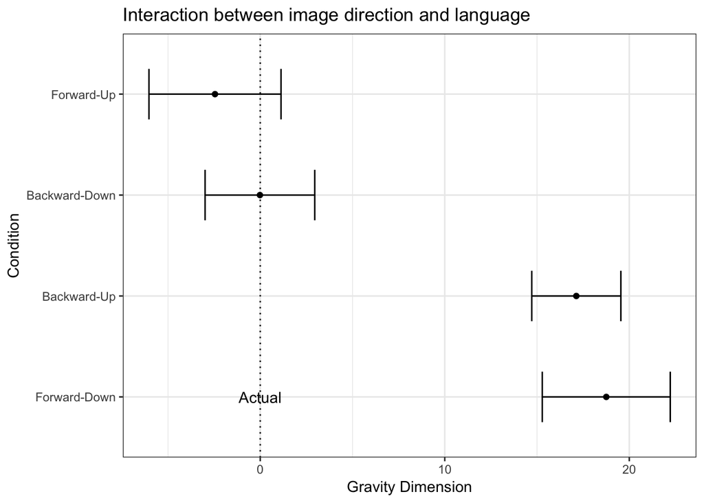

```r
#for sake of easy plotting make a new variable
results$cc = 0
results[results$lang=="forward" & results$dir=="up",]$cc="Forward-Up"
results[results$lang=="forward" & results$dir=="down",]$cc="Forward-Down"
results[results$lang=="backward" & results$dir=="up",]$cc="Backward-Up"
results[results$lang=="backward" & results$dir=="down",]$cc="Backward-Down"

#make a function for standard error bars:
stderr <- function(x) sqrt(var(x,na.rm=TRUE)/length(na.omit(x)))

#make the plot
library(doBy)
library(ggplot2)
library(scales)

means = summaryBy(newx ~ cc,  data = results,
          FUN = function(x) { c(m = mean(x), s = stderr(x)) } ) #-mean for exp 2?
means$x = c(2,5,6,1)
means$cc <- factor(means$cc, levels = means$cc[order(-means$x)])

ggplot(data=means,aes(newx.m,cc))+
  geom_point()+
  geom_errorbarh(aes(xmin=newx.m-newx.s,xmax=newx.m+newx.s,height=.5))+
  geom_vline(xintercept=c(0), linetype="dotted")+
  theme_bw()+
  ggtitle("Interaction between image direction and language")+
  #ggtitle("Experiment One")+
  xlab("Gravity Dimension") +
  ylab("Condition") +
  annotate("text", x = 0,y=1, label = "Actual")
```